# {ggplot2}

# Introduction

{Ggplot2} is the default tool for producing charts in R. There are many good books about it and the basic principles are a standard section of most R books. Here I would follow a similar approach as Cédric Scherer and go through the steps of modifying a ggplot (https://www.cedricscherer.com/2019/08/05/a-ggplot2-tutorial-for-beautiful-plotting-in-r/).

# Loading the data

```r
library(tidyverse)

df<- data.table::fread("data/gdp2v.csv") %>%
  filter(unit=="PPS_HAB_EU27_2020") %>%
filter(time == 2018) %>%
  mutate(country=str_sub(geo,1,2),
         NUTS=str_length(geo)-2) %>%
  filter(NUTS=="2") %>%
  select(-obs_decimals,-obs_status, -unit,-NUTS) %>%
  filter(!country %in% c("AL", "CY", "EE", "LU","LV","ME","MK","MT","NO","RS"))
```

```r
glimpse(df)
```

```
## Rows: 235
## Columns: 4
## $ geo       <chr> "AT12", "AT11", "AT34", "AT22", "AT13", "AT21", "AT31", "BE1~
## $ time      <int> 2018, 2018, 2018, 2018, 2018, 2018, 2018, 2018, 2018, 2018, ~
## $ obs_value <dbl> 105, 90, 144, 116, 151, 110, 131, 203, 152, 136, 115, 145, 1~
## $ country   <chr> "AT", "AT", "AT", "AT", "AT", "AT", "AT", "BE", "AT", "AT", ~
```

## A basic plot

We start by defining the dataset to use and the layout. In our case we will have the **country** in the **x** axis and the values in the **y** axis.

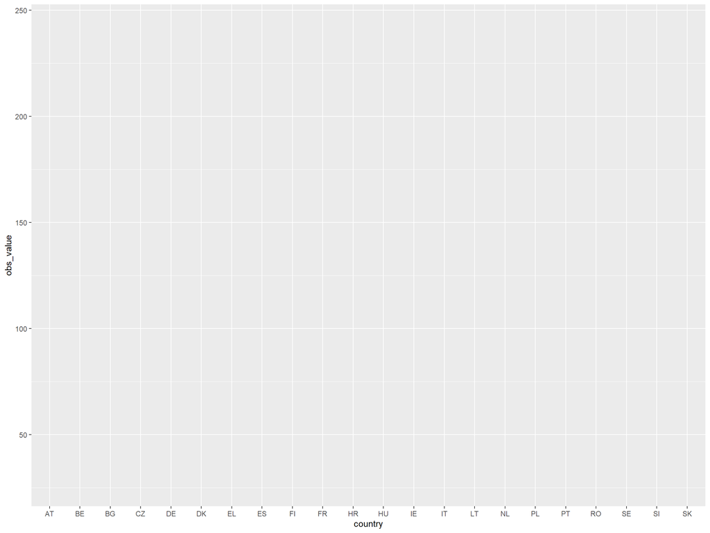

```r
(ggplot(df, aes(x= country, y= obs_value)))
```

Now we have to tell ggplot how do we want to plot the data. We use `geom_*`for that. Let’s say we want to plot dots.

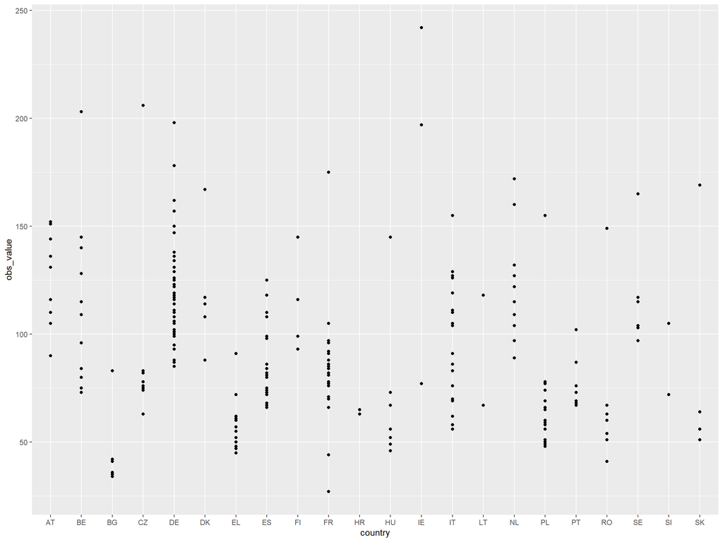

```r
g <- ggplot(df, aes(x= country, y= obs_value))

g + geom_point()
```

We could plot a line.

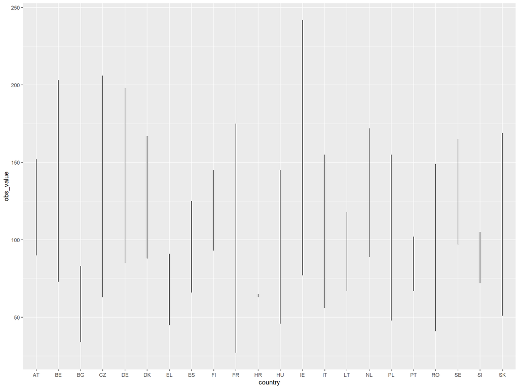

```r
g + geom_line()
```

Or a line and a dot.

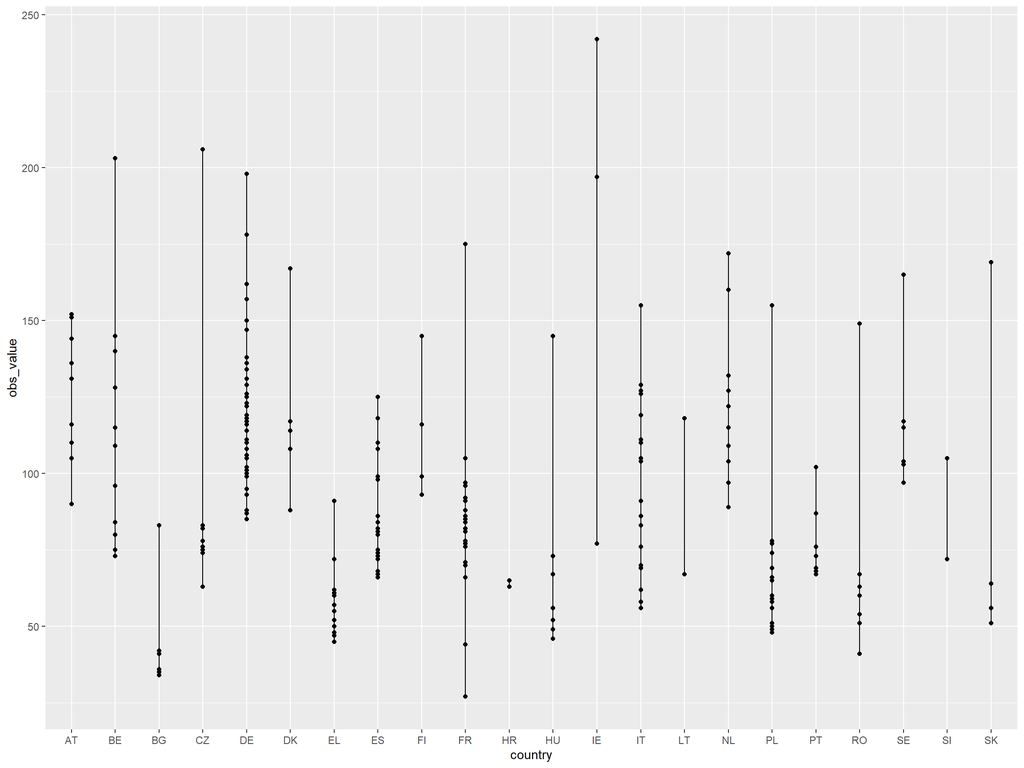

```r
g + geom_point() + geom_line()
```

Within `geom_*`we can control some aesthetics like colour, shape, size.

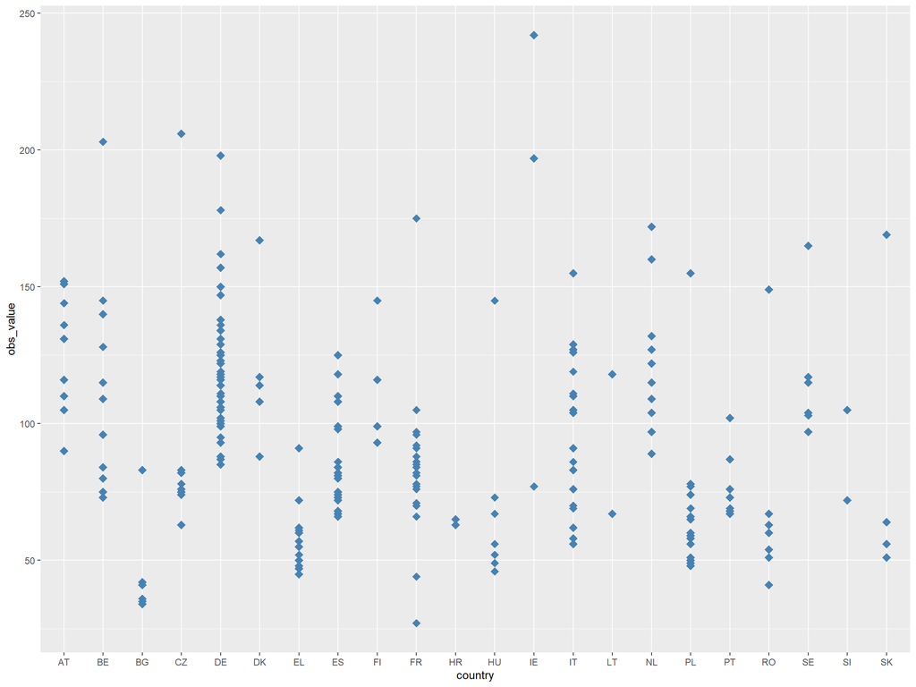

```r
g + geom_point (color="steelblue", size = 3.5, shape = "diamond")
```

Each `geom_` has its own arguments. For example there is no shape for `geom_line`or linetype for `geom_point`.

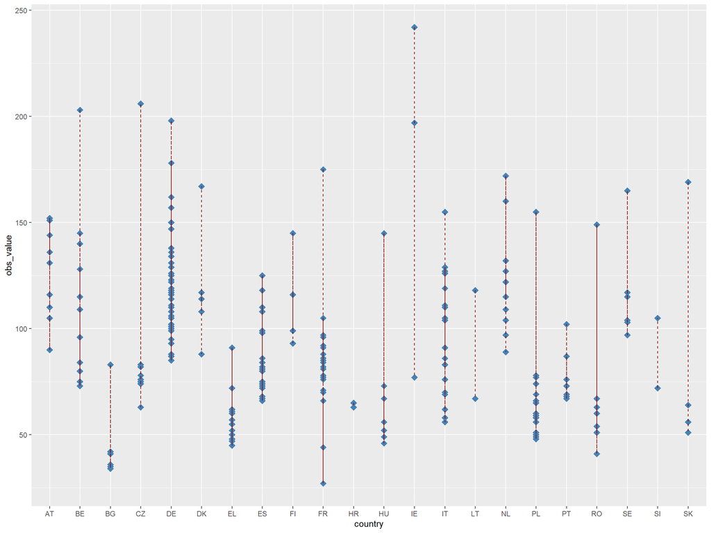

```r
g +
  geom_point (color="steelblue", size = 3.5, shape = "diamond")+
  geom_line(color="darkred", size = 0.5, linetype = "dashed")
```

Also the order of the geoms (which one shows first) affects the results.

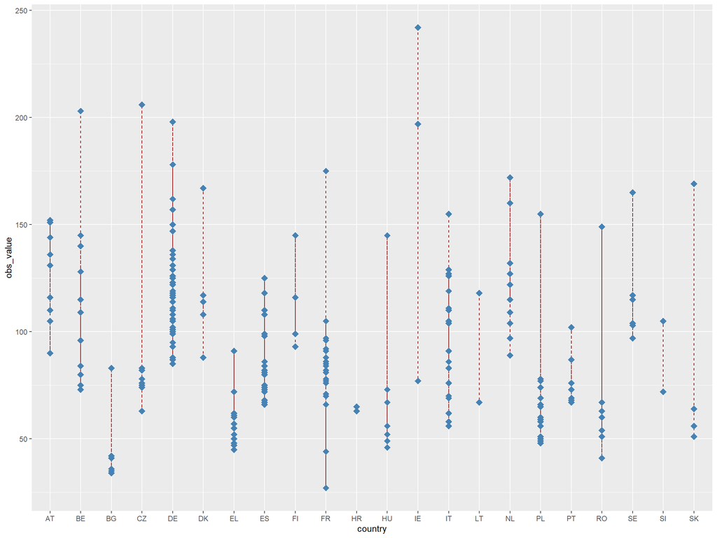

```r
g +
  geom_line(color="darkred", size = 0.5, linetype = "dashed")+
  geom_point (color="steelblue", size = 3.5, shape = "diamond")
```

We can change the default `theme` in ggplot. If we set the theme using `theme_set()` to {theme_bw} we do not have any longer the grey background and other aesthetics also change.

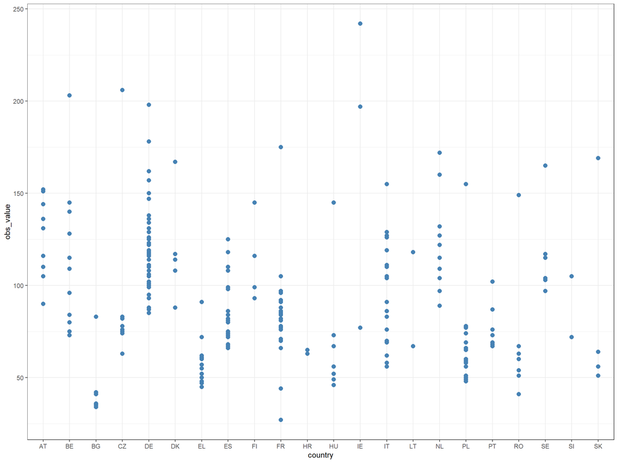

```r
theme_set(theme_bw())

g + geom_point(color = "steelblue", size =2.5)
```

You can override a particular thing of a theme, and there are many particular things (https://ggplot2.tidyverse.org/reference/theme.html). For example remove the minor gridlines.

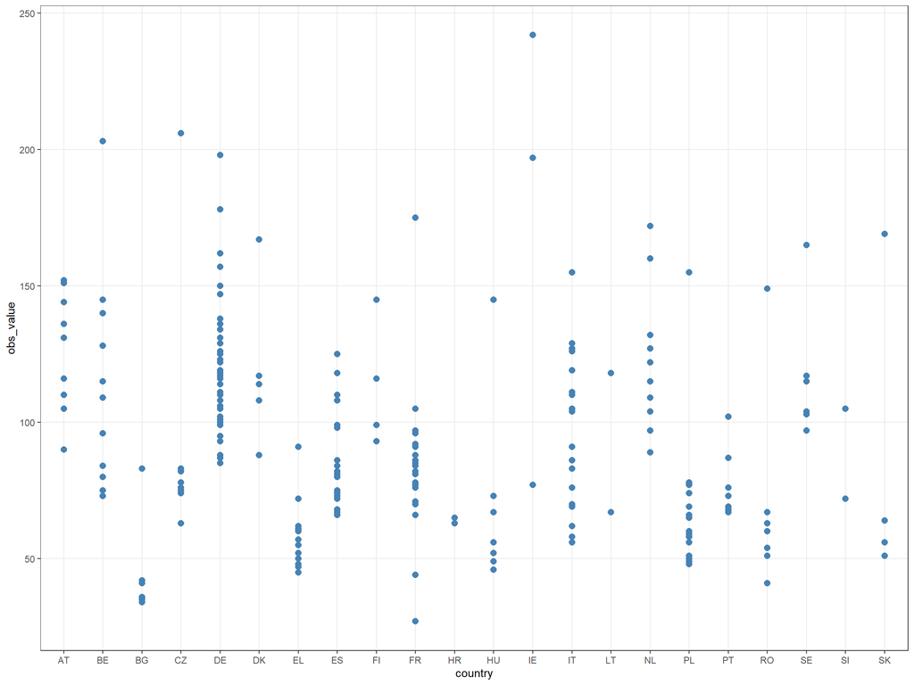

```r
g + geom_point(color = "steelblue", size =2.5)+
    theme(panel.grid.minor = element_blank())
```

# Axes

## Change Axis title

Let’s add some titles to the axes. We can do it with the function `labs`.

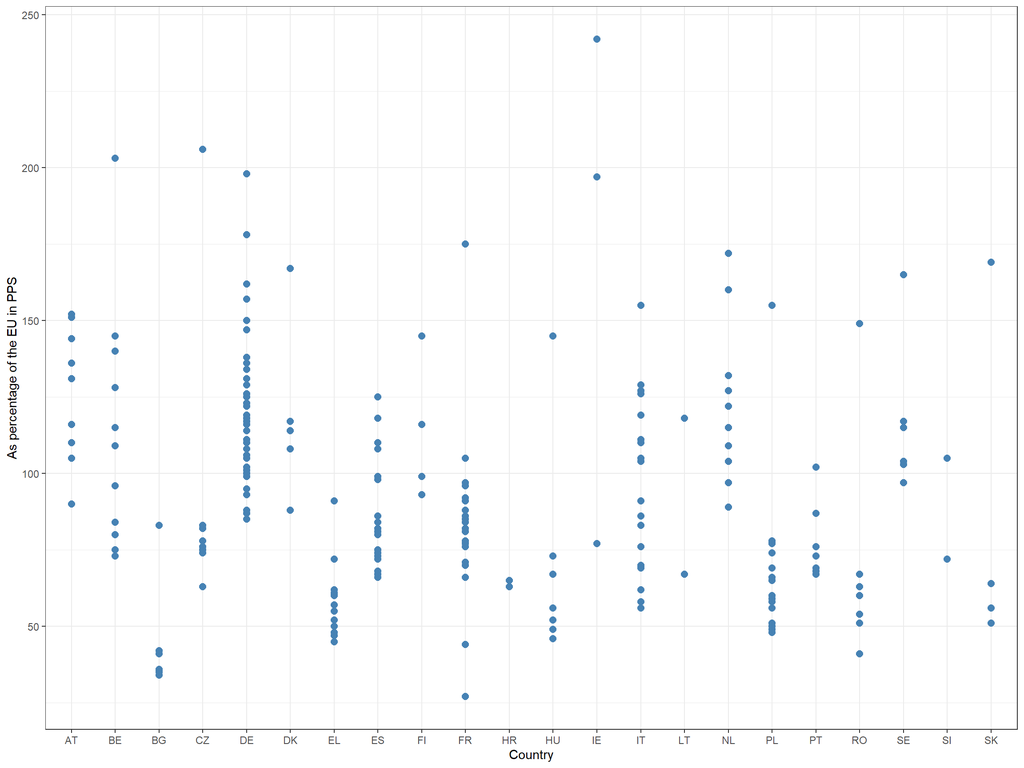

```r
g + geom_point(color = "steelblue", size =2.5)+
  labs( x = "Country",  y= "As percentage of the EU in PPS")
```

or with `xlab()` and `ylab()`

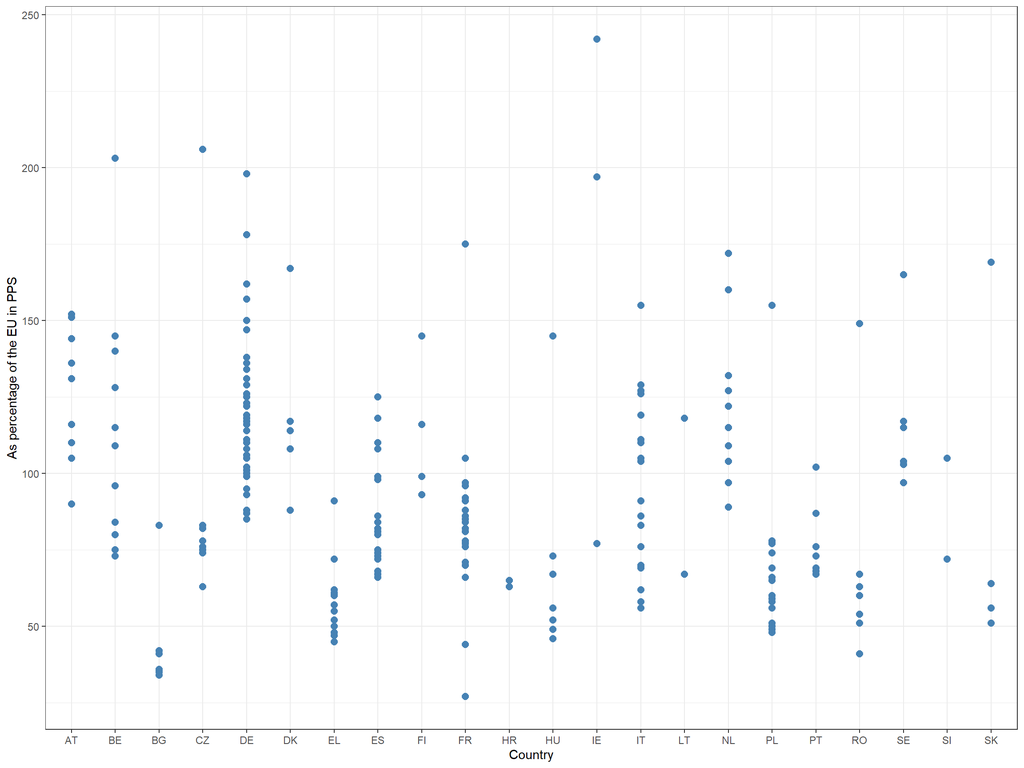

```r
g + geom_point(color = "steelblue", size =2.5)+
  xlab( "Country") +
  ylab( "As percentage of the EU in PPS")
```

We can add symbols, formulas or use superscripts:

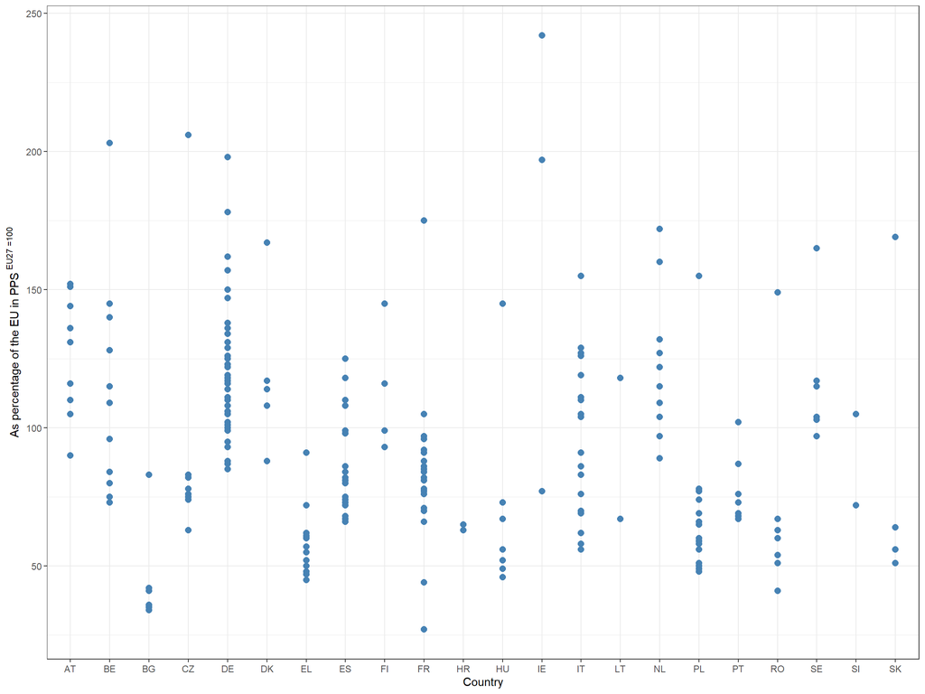

```r
g + geom_point(color = "steelblue", size =2.5)+
  labs( x = "Country",  y= expression(paste("As percentage of the EU in PPS" ^" EU27 =100")))
```

## Space between Axis and axis titles

We will use `theme()` to modify particular elements (text, background, boxes…). To modify text elements we use `element_text()`.

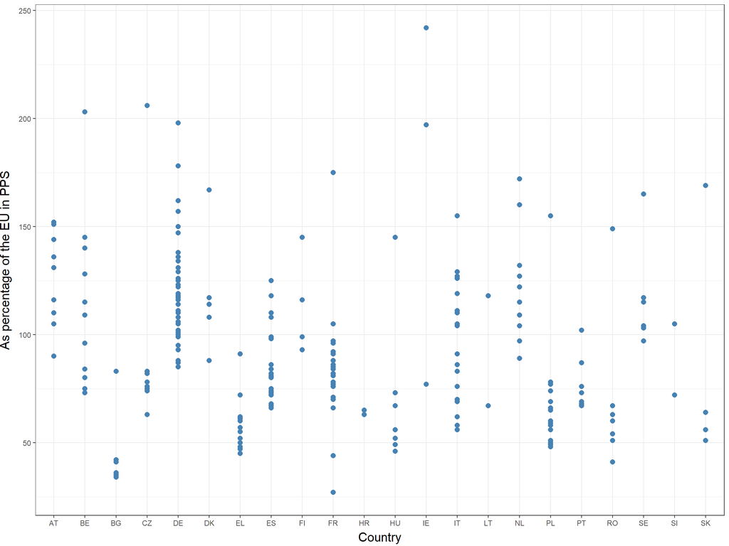

```r
ggplot(df, aes(x = country, y = obs_value)) +
  geom_point(color = "steelblue", size =2.5) +
  labs(x = "Country", y = "As percentage of the EU in PPS") +
  theme(axis.title.x = element_text(vjust = 0, size = 15),
        axis.title.y = element_text(vjust = 3, size = 15))
```

`vjust`refers to the vertical alignment.

We can do the same with `margin()`

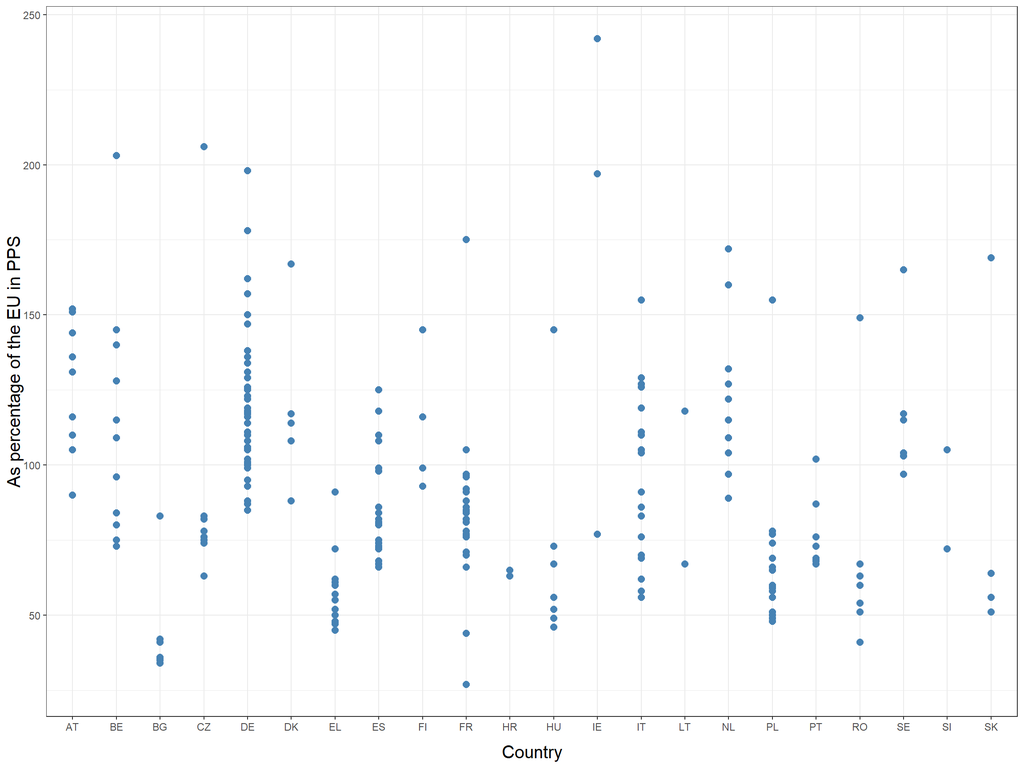

```r
ggplot(df, aes(x = country, y = obs_value)) +
  geom_point(color = "steelblue", size =2.5) +
  labs(x = "Country", y = "As percentage of the EU in PPS") +
  theme(axis.title.x = element_text(margin = margin(t = 10), size = 15),
        axis.title.y = element_text(margin = margin(t = 10), size = 15))
```

`margin()`takes the arguments `t` (top), `r` (right), `b` (bottom) and `l` (left).

## Change Aesthetics of Axis titles

With `axis.title`we can modify the size, colour and face (bold, italic or bold.italic.

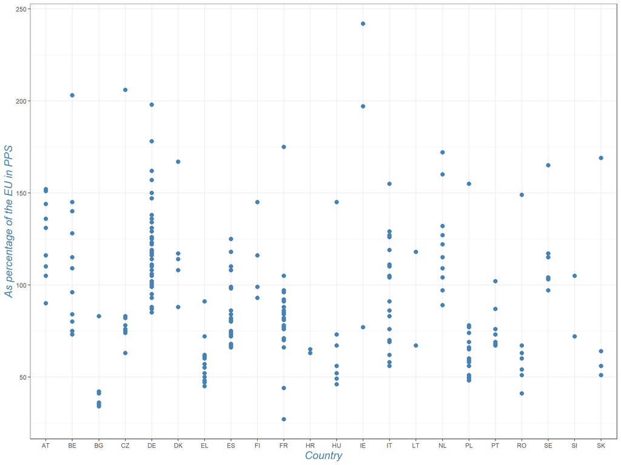

```r
ggplot(df, aes(x = country, y = obs_value)) +
  geom_point(color = "steelblue", size =2.5) +
   labs(x = "Country", y = "As percentage of the EU in PPS") +
  theme(axis.title = element_text(size = 15, color = "steelblue",
                                  face = "italic"))
```

We can do it individually for each axis (this is available in most options).

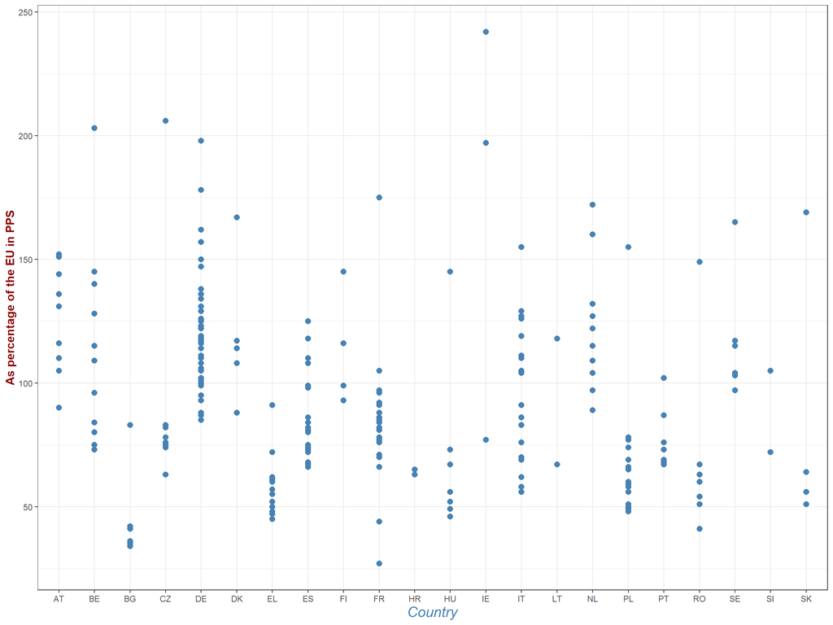

```r
ggplot(df, aes(x = country, y = obs_value)) +
  geom_point(color = "steelblue", size =2.5) +
   labs(x = "Country", y = "As percentage of the EU in PPS") +
  theme(axis.title.x = element_text(size = 15, color = "steelblue",
                                  face = "italic"),
        axis.title.y = element_text(size = 12, color = "darkred",
                                  face = "bold"))
```

## Change Aesthetics of Axis text

You can change the aesthetics of the axis text with `axis.text`.

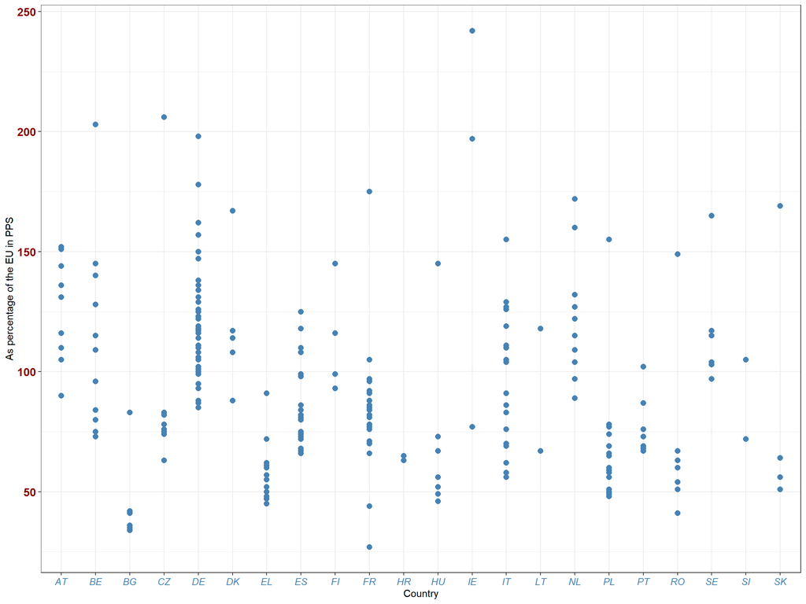

```r
ggplot(df, aes(x = country, y = obs_value)) +
  geom_point(color = "steelblue", size =2.5) +
   labs(x = "Country", y = "As percentage of the EU in PPS") +
  theme(axis.text.x = element_text(size = 10, color = "steelblue",
                                  face = "italic"),
        axis.text.y = element_text(size = 12, color = "darkred",
                                  face = "bold"))
```

## Rotate axis text

Specifying an `angle` allows you to rotate any text elements.

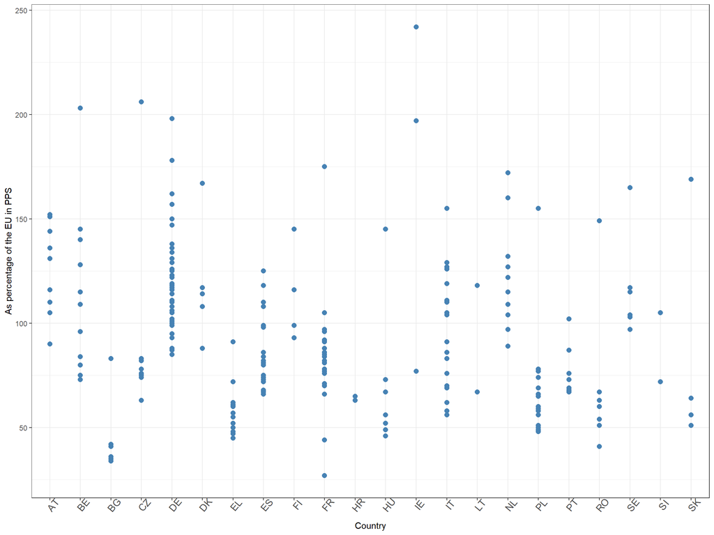

```r
ggplot(df, aes(x = country, y = obs_value)) +
  geom_point(color = "steelblue", size =2.5) +
   labs(x = "Country", y = "As percentage of the EU in PPS") +
  theme(axis.text.x = element_text(angle = 50, size = 12))
```

In that case w will normally need to adjust the distance to the axis.

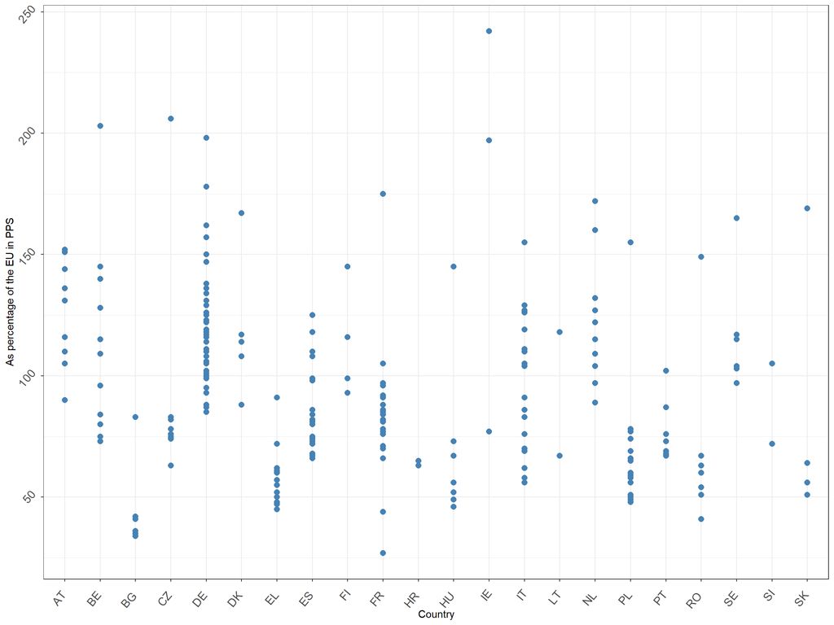

```r
ggplot(df, aes(x = country, y = obs_value)) +
  geom_point(color = "steelblue", size =2.5) +
   labs(x = "Country", y = "As percentage of the EU in PPS") +
  theme(axis.text.x = element_text(angle = 50, size = 12, hjust = 1.5),
        axis.text.y = element_text(angle = 50, size = 12, vjust = -0.5))
```

`hjust` and `vjust` are a bit confusing!

## Remove axis text and ticks

Not very recommended or usual but can be done. Most things are removed using `element_blank()`.

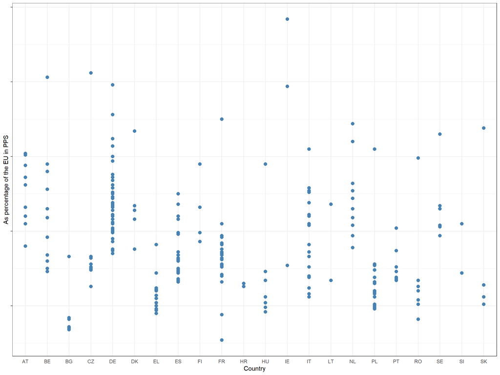

```r
ggplot(df, aes(x = country, y = obs_value)) +
  geom_point(color = "steelblue", size =2.5) +
   labs(x = "Country", y = "As percentage of the EU in PPS") +
   theme(axis.ticks.x = element_blank(),
        axis.text.y = element_blank())
```

There is `element_text`, `element_line`, `element_rectangle` and `element_blank`. We have seen so far `element_text`and `element_blank`.

## Remove Axis titles

This is more common as sometimes the title of the chart indicates it or is self-evident, like the x axis in our case.

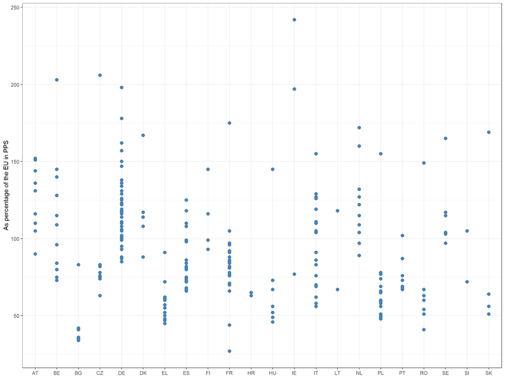

```r
ggplot(df, aes(x = country, y = obs_value)) +
  geom_point(color = "steelblue", size =2.5) +
   labs( y = "As percentage of the EU in PPS",
         x = NULL)
```

Sometimes you do not remember the option *NU* and force it to print nothing with `""`.

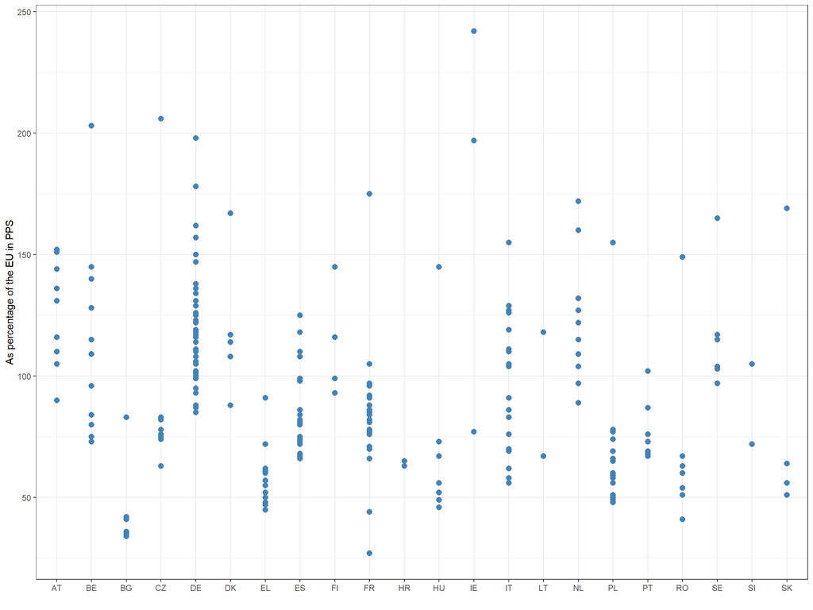

```r
ggplot(df, aes(x = country, y = obs_value)) +
  geom_point(color = "steelblue", size =2.5) +
   labs( y = "As percentage of the EU in PPS",
         x = "")
```

## Limit the Axis range

Sometimes you want to get a better view at some range of your data. You can do this without filtering your data:

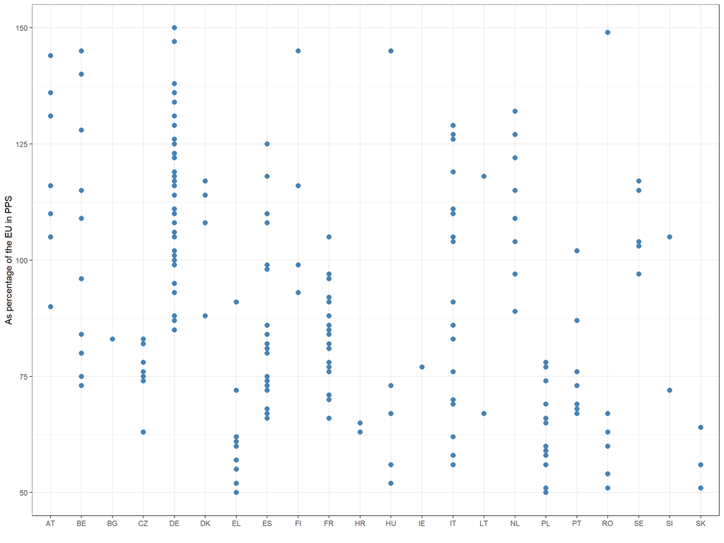

```r
ggplot(df, aes(x = country, y = obs_value)) +
  geom_point(color = "steelblue", size =2.5) +
   labs( y = "As percentage of the EU in PPS",
         x = "") +
    ylim(c(50, 150))
```

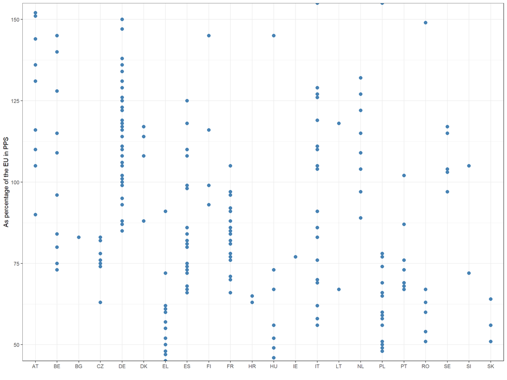

```r
ggplot(df, aes(x = country, y = obs_value)) +
  geom_point(color = "steelblue", size =2.5) +
   labs( y = "As percentage of the EU in PPS",
         x = "") +
 coord_cartesian(ylim = c(50, 150))
```

## Coordinates

Let’s change a bit our dataset to illustrate the point.

```r
df2 <-data.table::fread("data/gdp2v.csv") %>%
  filter(unit=="PPS_HAB_EU27_2020") %>%
filter(time == 2008| time == 2018) %>%
  pivot_wider(names_from = time,
              values_from = obs_value,
              names_prefix = "y") %>%
  mutate(country=str_sub(geo,1,2),
         NUTS=str_length(geo)-2) %>%
  filter(NUTS=="2") %>%
  select(-obs_decimals,-obs_status, -unit,-NUTS) %>%
  filter(!country %in% c("AL", "CY", "EE", "LU","LV","ME","MK","MT","NO","RS"))
```

Let force it to start at zero.

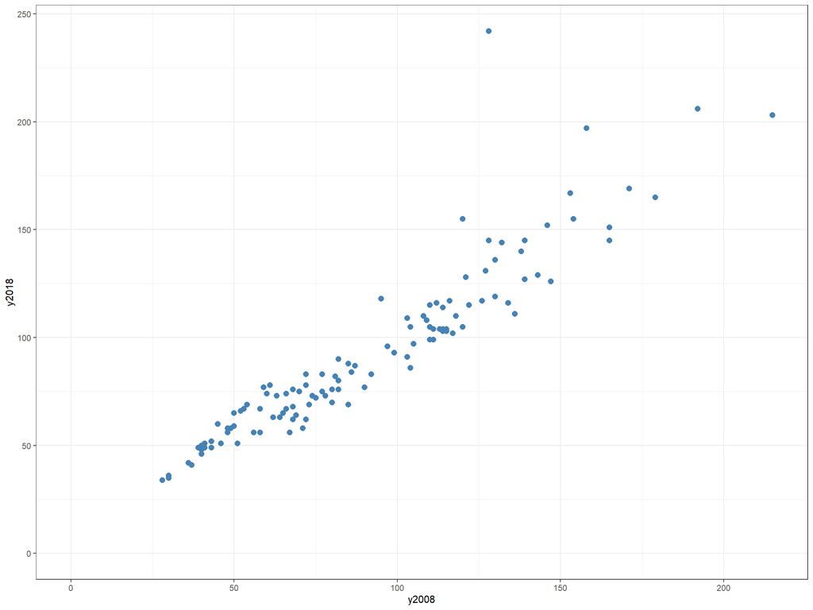

```r
ggplot(df2, aes(y2008,y2018))+
    geom_point(color = "steelblue", size =2.5) +
  expand_limits(x = 0, y = 0)
```

Really at zero!

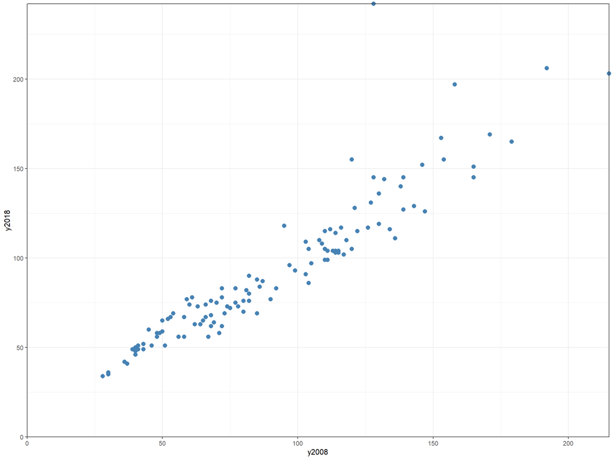

```r
ggplot(df2, aes(y2008,y2018))+
    geom_point(color = "steelblue", size =2.5) +
    expand_limits(x = 0, y = 0) +
  scale_x_continuous(expand = c(0, 0)) +
  scale_y_continuous(expand = c(0, 0)) +
  coord_cartesian(clip = "off")
```

The argument clip = “off” allows to draw outside the panel area.

## Scaling of the axis

We could force the ratio of the axis. The default, ratio = 1, ensures that one unit on the x-axis is the same length as one unit on the y-axis. It can be illustrated better in this chart.

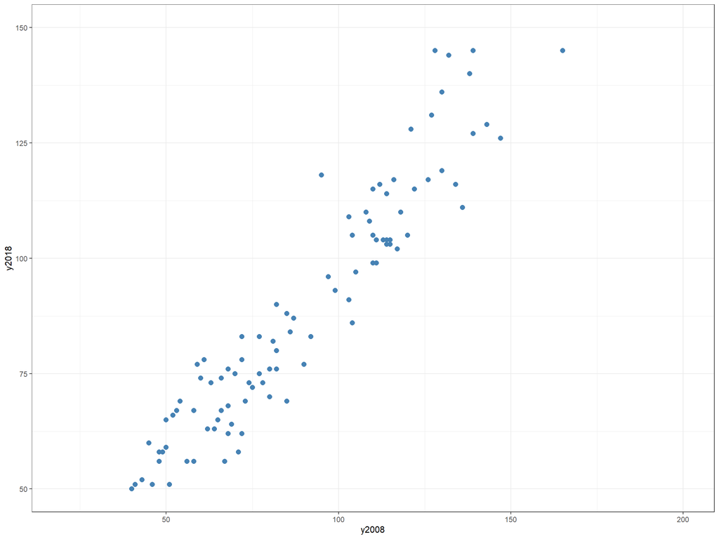

```r
ggplot(df2, aes(x = y2008, y = y2018)) +
  geom_point(color = "steelblue", size =2.5) +
    ylim(c(50, 150))+
   xlim (c(20,200))
```

Ratios higher than one in `coord_fixed()` make units on the y axis longer than units on the x-axis, and vice-versa.

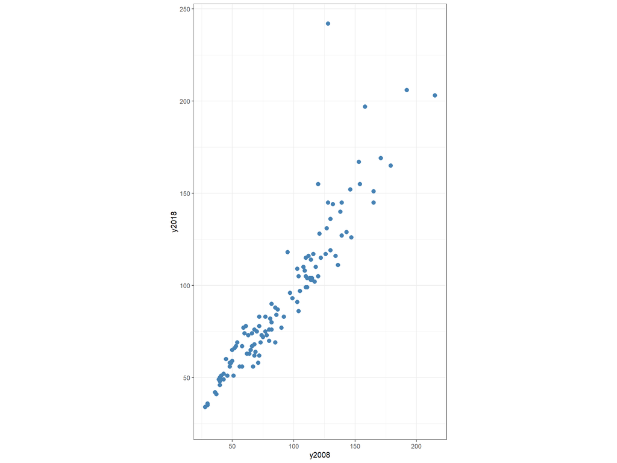

```r
ggplot(df2, aes(x = y2008, y = y2018)) +
  geom_point(color = "steelblue", size =2.5) +
coord_fixed(ratio = 1.5)
```

## Use a Function to Alter Labels

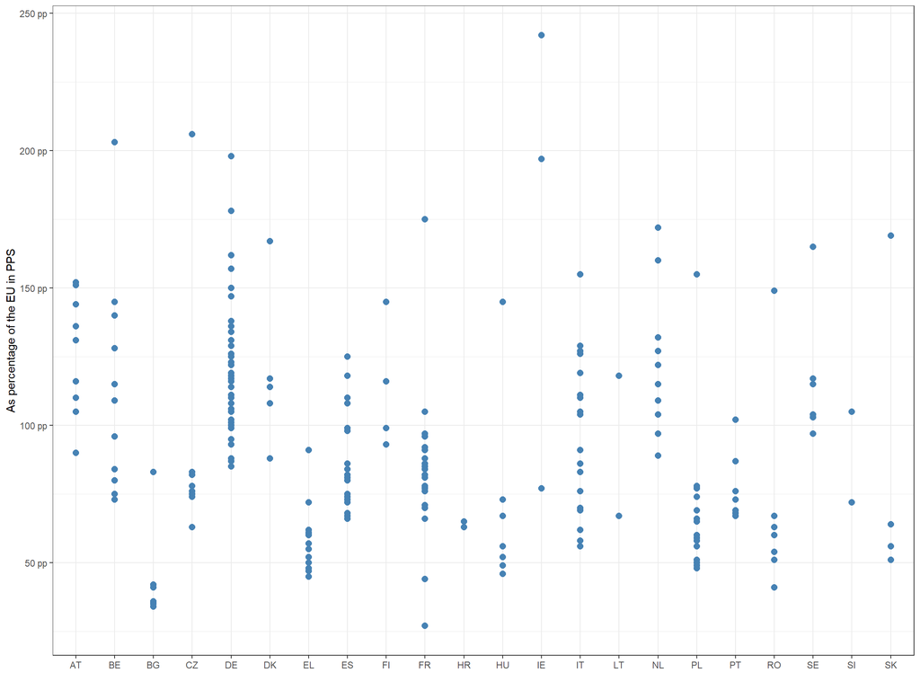

```r
ggplot(df, aes(x = country, y = obs_value)) +
  geom_point(color = "steelblue", size =2.5) +
   labs( y = "As percentage of the EU in PPS",
         x = "") +
  scale_y_continuous(label = function(x) {return(paste(x, "pp"))})
```

# Titles

We can add a simple title via the `ggtitle()` function:

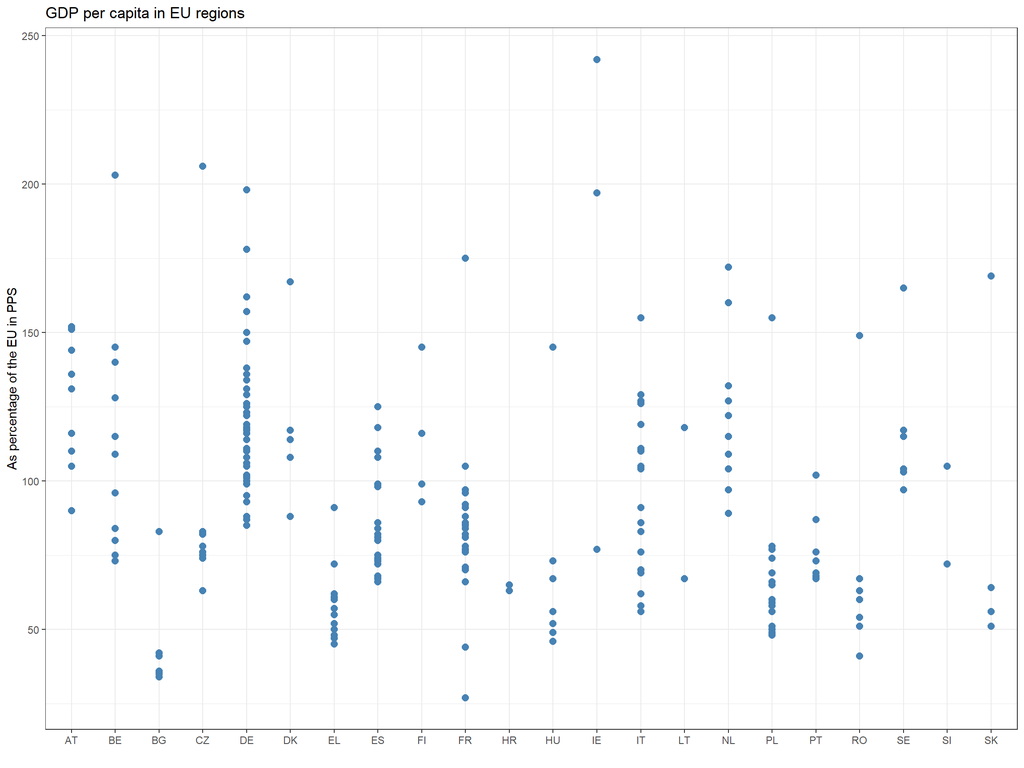

```r
ggplot(df, aes(x = country, y = obs_value)) +
  geom_point(color = "steelblue", size =2.5) +
   labs( y = "As percentage of the EU in PPS",
         x = "")+
  ggtitle ("GDP per capita in EU regions")
```

Or use `labs()` and add much more arguments.

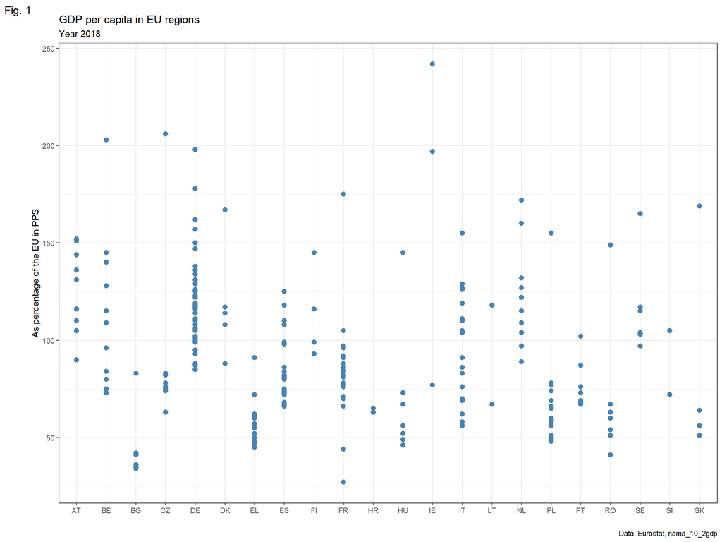

```r
ggplot(df, aes(x = country, y = obs_value)) +
  geom_point(color = "steelblue", size =2.5) +
   labs( y = "As percentage of the EU in PPS",
         x = "",
         title = "GDP per capita in EU regions",
       subtitle = "Year 2018",
       caption = "Data: Eurostat, nama_10_2gdp",
       tag = "Fig. 1")
```

## Adjust the title

We use `theme()`as we did with `axis.title` and `axis.text`. The same principles can be used for other elements `plot.subtitle`, `plot.caption`, `plot.caption`, `legend.title` and `legend.text`.

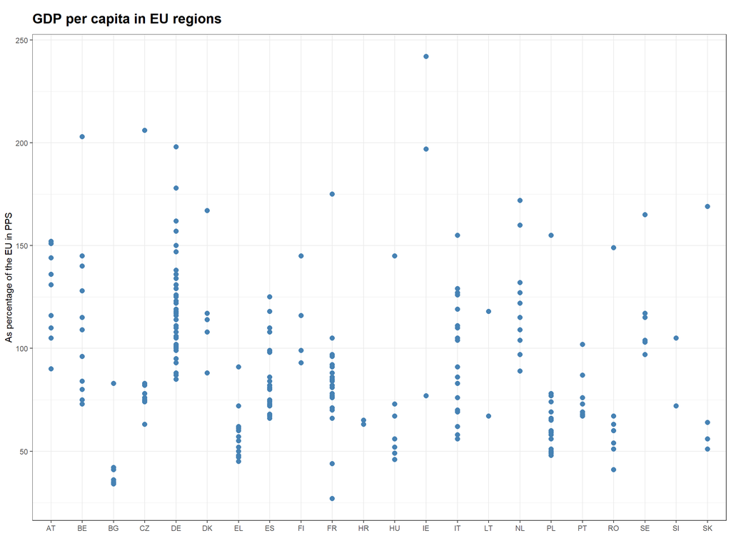

```r
ggplot(df, aes(x = country, y = obs_value)) +
  geom_point(color = "steelblue", size =2.5) +
   labs( y = "As percentage of the EU in PPS",
         x = "",
         title = "GDP per capita in EU regions")+
  theme(plot.title = element_text(face = "bold",
                                  margin = margin(10, 0, 10, 0),
                                  size = 16))
```